FJ

# Feidhelm Joyce

Business & Data Analyst  
Boston, MA

linkedin.com/in/feidhelmjoyce  
github.com/FeidhelmJ

HomeProfessional SummaryMarketing AnalyticsFinancial AnalyticsData Mining for Business AnalyticsCloud AnalyticsProjectsSkillsContact

DATA MINING FOR BUSINESS ANALYTICS

## Data Exploration & Cleaning

← Back to Data Mining for Business Analytics

```
import pandas as pd
import seaborn as sns
import matplotlib.pyplot as plt
import numpy as np
```

```
chicago = pd.read_csv("chicago_violations.csv")
```

```
pd.set_option('display.max_columns', None)
```

```
chicago.head()
```

|  | ID | DOCKET NUMBER | NOV NUMBER | ADDRESS | STREET NUMBER | STREET DIRECTION | STREET NAME | STREET TYPE | WARD | ISSUING DEPARTMENT | HEARING DATE | CASE DISPOSITION | IMPOSED FINE | ADMIN COSTS | LAST MODIFIED DATE | VIOLATION DATE | VIOLATION CODE | VIOLATION DESCRIPTION | RESPONDENTS | LATITUDE | LONGITUDE | LOCATION |
| --- | --- | --- | --- | --- | --- | --- | --- | --- | --- | --- | --- | --- | --- | --- | --- | --- | --- | --- | --- | --- | --- | --- |
| 0 | 9ed845888ab5e3bc6516adebba3319346b173012 | 23BT00101A | 22P0675219 | 5006 W GUNNISON ST | 5006 | W | GUNNISON | ST | 45.0 | Buildings | 02/15/2023 | Default | 2500.0 | 40 | 02/15/2023 04:55:46 PM | 12/12/2022 09:00:00 AM | 234024 | Provide vent stack or main vent pipe of proper... | C/O EMILIA CRESPO RCI CONSTRUCTION LLC | 41.968987 | -87.753001 | (41.968987073274285, -87.75300053512358) |
| 1 | b6df42910398cd4144f06d4ae36a25681848146b | 15BT03446A | 15WO442772 | 3241 W 62ND ST | 3241 | W | 62ND | ST | 23.0 | Buildings | 07/18/2016 | Liable | 300.0 | 75 | 08/16/2016 10:07:35 AM | 06/02/2015 09:00:00 AM | 074024 | Provide guard rail at least 3 ft high. (13-124... | JOSE ANTONIO | 41.780664 | -87.704811 | (41.78066412138804, -87.70481149542081) |
| 2 | de16ff67b156537113e2e7ecb1d18044e268aa3a | 22BT02866A | 22T0668607 | 3811 W 61ST ST | 3811 | W | 61ST | ST | 23.0 | Buildings | 02/15/2023 | Non-Suit | 0.0 | 0 | 02/15/2023 04:08:02 PM | 08/19/2022 09:00:00 AM | 002022 | Description of work: | PROTILE CONSTRUCTION INC C/O JOSE J REYES | 41.782256 | -87.718458 | (41.78225587973938, -87.71845756904534) |
| 3 | ff933be74d08113f113a3ba84fa0f2652a017991 | 21BT02435A | 21V0652277 | 4259 W WILCOX ST | 4259 | W | WILCOX | ST | 28.0 | Buildings | 03/14/2022 | Default | 500.0 | 40 | 02/15/2023 12:09:07 PM | 10/12/2021 09:00:00 AM | 253020 | Maintain mechanical ventilation system in good... | MINOO PATEL \| NITI VAISH | 41.878674 | -87.732835 | (41.8786739171648, -87.7328354313118) |
| 4 | fecf777cc540db1cf9abd2e72b0d839868dd2515 | 22BT03788A | 22SH0674660 | 1614 W 66TH ST | 1614 | W | 66TH | ST | 15.0 | Buildings | 02/15/2023 | Non-Suit | 0.0 | 0 | 02/15/2023 01:31:06 PM | 12/06/2022 12:00:00 AM | 197087 | Install carbon monoxide detector within 40 fee... | C/O BUSINESS FILINGS INCORPORATED ABERDEEN GRE... | 41.774114 | -87.664750 | (41.77411365454302, -87.66474985373549) |

```
chicago.tail()
```

|  | ID | DOCKET NUMBER | NOV NUMBER | ADDRESS | STREET NUMBER | STREET DIRECTION | STREET NAME | STREET TYPE | WARD | ISSUING DEPARTMENT | HEARING DATE | CASE DISPOSITION | IMPOSED FINE | ADMIN COSTS | LAST MODIFIED DATE | VIOLATION DATE | VIOLATION CODE | VIOLATION DESCRIPTION | RESPONDENTS | LATITUDE | LONGITUDE | LOCATION |
| --- | --- | --- | --- | --- | --- | --- | --- | --- | --- | --- | --- | --- | --- | --- | --- | --- | --- | --- | --- | --- | --- | --- |
| 784220 | 2be987d873279f28914340d5bb94f1ade6749f55 | 23BT02099A | 23S0686227 | 6832 S SANGAMON ST | 6832 | S | SANGAMON | ST | 6.0 | Buildings | 09/12/2023 | Default | 4000.0 | 40 | 09/12/2023 11:39:59 AM | 06/21/2023 09:00:00 AM | 197019 | Install and maintain approved smoke detectors.... | JEBB FOOD SERVICES, INC C/O BLANCA CRUZ | 41.769605 | -87.648304 | (41.76960538317748, -87.64830441529664) |
| 784221 | 426ab125b433243848e4c73b3fbc4093be328bcd | 22BT02297A | 22T0665695 | 5535 W POTOMAC AVE | 5535 | W | POTOMAC | AVE | 37.0 | Buildings | 09/12/2023 | Liable | 500.0 | 100 | 09/12/2023 11:39:13 AM | 06/29/2022 09:00:00 AM | 002022 | Description of work: | C/O IGOR GONCHARKO 1255 N CENTRAL LLC | 41.903846 | -87.765378 | (41.90384574213776, -87.76537838334524) |
| 784222 | b330a8a09acd231ff9650eae8aaa4e61ddd45e5b | 23BT02100A | 23W0686238 | 4400 W WASHINGTON BLVD | 4400 | W | WASHINGTON | BLVD | 28.0 | Buildings | 09/12/2023 | Default | 4500.0 | 40 | 09/12/2023 11:30:48 AM | 06/02/2023 09:00:00 AM | 065034 | Replace defective window sills. (13-196-550) | 4200 W WASHINGTON BLVD HOLDINGS LLC C/O BRIAN ... | 41.882036 | -87.735641 | (41.88203637614127, -87.7356411955985) |
| 784223 | a6a6363f588abb0471009657d96316f8bbac4fa4 | 23BT02099A | 23S0686227 | 6832 S SANGAMON ST | 6832 | S | SANGAMON | ST | 6.0 | Buildings | 09/12/2023 | Default | 4000.0 | 40 | 09/12/2023 11:39:59 AM | 06/21/2023 09:00:00 AM | 131016 | Screen outer doors, windows, and other outer o... | JEBB FOOD SERVICES, INC C/O BLANCA CRUZ | 41.769605 | -87.648304 | (41.76960538317748, -87.64830441529664) |
| 784224 | ecce6ef33fec12916101cb34312fc1248ddfc911 | 23BT02068A | 23N0685838 | 6756 S MORGAN ST | 6756 | S | MORGAN | ST | 6.0 | Buildings | 09/12/2023 | Non-Suit | 0.0 | 0 | 09/12/2023 11:03:17 AM | 06/08/2023 09:00:00 AM | 106015 | Repair or replace defective or missing members... | LONNE NORMAN | 41.770728 | -87.649557 | (41.770728355326284, -87.64955741182487) |

Q.2

Read this file using pandas.

1. Describe the dataset.
- The data consists of over 700,000 entries across 22 columns. 16 columns are object data types which contain mostly string/text characters. 4 columns float64 are data types which are numeric with decimals. 2 columns are int64 which are numeric columns only containing whole numbers.
- The columns are made up of mostly categorical variables but there are some numeric variables listed too such as 'IMPOSED FINE' & 'ADMIN COSTS'.
- There are some missing values in the dataset across a number of variables such as 'WARD', 'CASE DISPOSITION', 'LATITUDE', 'LONGTITUDE' & 'LOCATION'.
2. How many rows and how many columns does your dataframe contain?
- 784,225 Rows
- 22 Columns

```
chicago.info()
```

```
<class 'pandas.core.frame.DataFrame'>
RangeIndex: 784225 entries, 0 to 784224
Data columns (total 22 columns):
 #   Column                 Non-Null Count   Dtype
---  ------                 --------------   -----
 0   ID                     784225 non-null  object
 1   DOCKET NUMBER          784122 non-null  object
 2   NOV NUMBER             784225 non-null  object
 3   ADDRESS                784225 non-null  object
 4   STREET NUMBER          784225 non-null  int64
 5   STREET DIRECTION       784219 non-null  object
 6   STREET NAME            784225 non-null  object
 7   STREET TYPE            776027 non-null  object
 8   WARD                   781415 non-null  float64
 9   ISSUING DEPARTMENT     784225 non-null  object
 10  HEARING DATE           784122 non-null  object
 11  CASE DISPOSITION       766095 non-null  object
 12  IMPOSED FINE           784225 non-null  float64
 13  ADMIN COSTS            784225 non-null  int64
 14  LAST MODIFIED DATE     784225 non-null  object
 15  VIOLATION DATE         784132 non-null  object
 16  VIOLATION CODE         784225 non-null  object
 17  VIOLATION DESCRIPTION  784225 non-null  object
 18  RESPONDENTS            784225 non-null  object
 19  LATITUDE               783289 non-null  float64
 20  LONGITUDE              783289 non-null  float64
 21  LOCATION               783289 non-null  object
dtypes: float64(4), int64(2), object(16)
memory usage: 131.6+ MB
```

```
chicago.shape

len(chicago)
```

```
784225
```

Q.3 Choose a ward number at random without consulting anyone else. Filter your dataset, so that it only contains records with your chosen ward.

1. How many records does your dataframe contain now?
- 21,440 Rows
- 22 Columns
2. Identify at least three interesting facts about your ward. You may use any source to find this information – it will not come from within this dataset. You can list them here in any format (bullet points, full sentences, etc.) No links or citations are needed.
- Chicago's 9th Ward is notable for the historic Pullman neighborhood, its status as one of the city's largest wards, and the long-standing tenure of its current alderman.
- Located on the far South Side of the city, is one of the largest of the 50 wards. The ward includes 6 of these historic and diverse community areas, Chatham, Roseland, Pullman, Washington Heights, West Pullman and Riverdale.
- Roseland began as a Dutch truck farm community called "Hope." Roseland is the community featured in Edna Ferber's novel, "So Big," which won a Pulitzer Prize, in 1924.
- The neighborhood was built in 1880 by railroad industrialist George Pullman as one of the country's first planned industrial communities

```
chicago_ward_9 = chicago[chicago['WARD'] == 9.0].copy()
chicago_ward_9.head()
```

|  | ID | DOCKET NUMBER | NOV NUMBER | ADDRESS | STREET NUMBER | STREET DIRECTION | STREET NAME | STREET TYPE | WARD | ISSUING DEPARTMENT | HEARING DATE | CASE DISPOSITION | IMPOSED FINE | ADMIN COSTS | LAST MODIFIED DATE | VIOLATION DATE | VIOLATION CODE | VIOLATION DESCRIPTION | RESPONDENTS | LATITUDE | LONGITUDE | LOCATION |
| --- | --- | --- | --- | --- | --- | --- | --- | --- | --- | --- | --- | --- | --- | --- | --- | --- | --- | --- | --- | --- | --- | --- |
| 310 | a2c24a914232c20a1f98a75387bb2a3cf9deed9d | 22BT01452A | 22SO660710 | 630 E 102ND PL | 630 | E | 102ND | PL | 9.0 | Buildings | 02/21/2023 | Non-Suit | 0.0 | 0 | 02/21/2023 11:22:06 AM | 04/04/2022 09:00:00 AM | 041063 | Cut or remove high weeds that present a fire h... | ALICE JOHNSON \| ROBERT JOHNSON | 41.708429 | -87.607654 | (41.70842885797337, -87.6076543857071) |
| 333 | d598743ba985a4760a5ab91cecdd133983c95e7f | 22BT01452A | 22SO660710 | 630 E 102ND PL | 630 | E | 102ND | PL | 9.0 | Buildings | 02/21/2023 | Non-Suit | 0.0 | 0 | 02/21/2023 11:22:06 AM | 04/04/2022 09:00:00 AM | 074014 | Repair or rebuild exterior service walks, pass... | ALICE JOHNSON \| ROBERT JOHNSON | 41.708429 | -87.607654 | (41.70842885797337, -87.6076543857071) |
| 339 | e1cb44e8e0efab5aa75e59bf716e861226e7fc33 | 22BT01452A | 22SO660710 | 630 E 102ND PL | 630 | E | 102ND | PL | 9.0 | Buildings | 02/21/2023 | Non-Suit | 0.0 | 0 | 02/21/2023 11:22:06 AM | 04/04/2022 09:00:00 AM | 073024 | Repair or replace defective door frame. (13-19... | ALICE JOHNSON \| ROBERT JOHNSON | 41.708429 | -87.607654 | (41.70842885797337, -87.6076543857071) |
| 340 | f62e2c6f3e6c9ec68bfad343b6f66b88b0928eee | 22BT01452A | 22SO660710 | 630 E 102ND PL | 630 | E | 102ND | PL | 9.0 | Buildings | 02/21/2023 | Non-Suit | 0.0 | 0 | 02/21/2023 11:22:06 AM | 04/04/2022 09:00:00 AM | 079014 | Repair or rebuild defective members of garage ... | ALICE JOHNSON \| ROBERT JOHNSON | 41.708429 | -87.607654 | (41.70842885797337, -87.6076543857071) |
| 346 | ba33d10a4186007e2b56a4906369f55cadb0df73 | 09BS10671A | 09SO229529 | 10418 S DR MARTIN LUTHER KING JR DR | 10418 | S | DR MARTIN LUTHER KING JR | DR | 9.0 | Buildings | 06/17/2010 | Liable | 300.0 | 75 | 03/01/2013 03:39:11 AM | 09/02/2009 08:23:00 AM | 065034 | Replace defective window sills. (13-196-550) | EUGENE NOEL | 41.704886 | -87.613851 | (41.704885690487565, -87.61385051928933) |

```
chicago_ward_9.info()
```

```
<class 'pandas.core.frame.DataFrame'>
Index: 21440 entries, 310 to 784018
Data columns (total 22 columns):
 #   Column                 Non-Null Count  Dtype
---  ------                 --------------  -----
 0   ID                     21440 non-null  object
 1   DOCKET NUMBER          21440 non-null  object
 2   NOV NUMBER             21440 non-null  object
 3   ADDRESS                21440 non-null  object
 4   STREET NUMBER          21440 non-null  int64
 5   STREET DIRECTION       21440 non-null  object
 6   STREET NAME            21440 non-null  object
 7   STREET TYPE            21430 non-null  object
 8   WARD                   21440 non-null  float64
 9   ISSUING DEPARTMENT     21440 non-null  object
 10  HEARING DATE           21440 non-null  object
 11  CASE DISPOSITION       20956 non-null  object
 12  IMPOSED FINE           21440 non-null  float64
 13  ADMIN COSTS            21440 non-null  int64
 14  LAST MODIFIED DATE     21440 non-null  object
 15  VIOLATION DATE         21438 non-null  object
 16  VIOLATION CODE         21440 non-null  object
 17  VIOLATION DESCRIPTION  21440 non-null  object
 18  RESPONDENTS            21440 non-null  object
 19  LATITUDE               21440 non-null  float64
 20  LONGITUDE              21440 non-null  float64
 21  LOCATION               21440 non-null  object
dtypes: float64(4), int64(2), object(16)
memory usage: 3.8+ MB
```

Q.4 Dealing with NA data.

1. Are there any NA values in your dataframe? How do you know this? What is the total number of NAs in the dataframe?
- There are 10 Na values in Street Type, 484 Na values in Case Disposition & 2 Na values in Violation Date found using the code below.
2. What percentage of the rows in the dataframe are complete cases? What is a complete case?
- 97.69% when rounded to 2 decimal places.
- A complete case is a row that contains no missing values across any column.
3. Convert any blank cells in the dataframe into NAs.
4. Generate a table that shows the number of missing values and the percentage of missing values for each variable.

```
missing_count = chicago_ward_9.isna().sum()
missing_count
```

|  | 0 |
| --- | --- |
| ID | 0 |
| DOCKET NUMBER | 0 |
| NOV NUMBER | 0 |
| ADDRESS | 0 |
| STREET NUMBER | 0 |
| STREET DIRECTION | 0 |
| STREET NAME | 0 |
| STREET TYPE | 10 |
| WARD | 0 |
| ISSUING DEPARTMENT | 0 |
| HEARING DATE | 0 |
| CASE DISPOSITION | 484 |
| IMPOSED FINE | 0 |
| ADMIN COSTS | 0 |
| LAST MODIFIED DATE | 0 |
| VIOLATION DATE | 2 |
| VIOLATION CODE | 0 |
| VIOLATION DESCRIPTION | 0 |
| RESPONDENTS | 0 |
| LATITUDE | 0 |
| LONGITUDE | 0 |
| LOCATION | 0 |

```
total_rows = len(chicago_ward_9)
complete_rows = len(chicago_ward_9.dropna())
percent_complete = (complete_rows / total_rows) * 100
incomplete_rows = total_rows - complete_rows
```

```
percent_complete
```

```
97.68656716417911
```

```
incomplete_rows
```

```
496
```

```
chicago_ward_9 = chicago_ward_9.replace(r'^\s*$', np.nan, regex=True)
```

```
missing_percent = (missing_count / len(chicago_ward_9)) * 100
```

```
missing_table = pd.DataFrame({'Missing Values': missing_count,'% Missing': missing_percent})
missing_table
```

|  | Missing Values | % Missing |
| --- | --- | --- |
| ID | 0 | 0.000000 |
| DOCKET NUMBER | 0 | 0.000000 |
| NOV NUMBER | 0 | 0.000000 |
| ADDRESS | 0 | 0.000000 |
| STREET NUMBER | 0 | 0.000000 |
| STREET DIRECTION | 0 | 0.000000 |
| STREET NAME | 0 | 0.000000 |
| STREET TYPE | 10 | 0.046642 |
| WARD | 0 | 0.000000 |
| ISSUING DEPARTMENT | 0 | 0.000000 |
| HEARING DATE | 0 | 0.000000 |
| CASE DISPOSITION | 484 | 2.257463 |
| IMPOSED FINE | 0 | 0.000000 |
| ADMIN COSTS | 0 | 0.000000 |
| LAST MODIFIED DATE | 0 | 0.000000 |
| VIOLATION DATE | 2 | 0.009328 |
| VIOLATION CODE | 0 | 0.000000 |
| VIOLATION DESCRIPTION | 0 | 0.000000 |
| RESPONDENTS | 0 | 0.000000 |
| LATITUDE | 0 | 0.000000 |
| LONGITUDE | 0 | 0.000000 |
| LOCATION | 0 | 0.000000 |

Q5. Handling Dates

1. Which variables in this dataset contain date values?
- Hearing Date, Last Modified Date, Violation Date
2. Now, add a new variable to the dataframe called CityDelay. CityDelay should be created based on the difference between the HearingDate and ViolationDate.
3. What is your birthday? (just use the day/month for this, not the year)
- 29/06
4. How many ordinance violations were issued on your birthday? What was the most common Case Disposition for those ordinance violations? [Note: if you built a separate dataframe to answer this, just think of that dataframe as its own island – you won’t use it for any subsequent steps].
- 82
- Liable

```
chicago_ward_9.head()
```

|  | ID | DOCKET NUMBER | NOV NUMBER | ADDRESS | STREET NUMBER | STREET DIRECTION | STREET NAME | STREET TYPE | WARD | ISSUING DEPARTMENT | HEARING DATE | CASE DISPOSITION | IMPOSED FINE | ADMIN COSTS | LAST MODIFIED DATE | VIOLATION DATE | VIOLATION CODE | VIOLATION DESCRIPTION | RESPONDENTS | LATITUDE | LONGITUDE | LOCATION |
| --- | --- | --- | --- | --- | --- | --- | --- | --- | --- | --- | --- | --- | --- | --- | --- | --- | --- | --- | --- | --- | --- | --- |
| 310 | a2c24a914232c20a1f98a75387bb2a3cf9deed9d | 22BT01452A | 22SO660710 | 630 E 102ND PL | 630 | E | 102ND | PL | 9.0 | Buildings | 02/21/2023 | Non-Suit | 0.0 | 0 | 02/21/2023 11:22:06 AM | 04/04/2022 09:00:00 AM | 041063 | Cut or remove high weeds that present a fire h... | ALICE JOHNSON \| ROBERT JOHNSON | 41.708429 | -87.607654 | (41.70842885797337, -87.6076543857071) |
| 333 | d598743ba985a4760a5ab91cecdd133983c95e7f | 22BT01452A | 22SO660710 | 630 E 102ND PL | 630 | E | 102ND | PL | 9.0 | Buildings | 02/21/2023 | Non-Suit | 0.0 | 0 | 02/21/2023 11:22:06 AM | 04/04/2022 09:00:00 AM | 074014 | Repair or rebuild exterior service walks, pass... | ALICE JOHNSON \| ROBERT JOHNSON | 41.708429 | -87.607654 | (41.70842885797337, -87.6076543857071) |
| 339 | e1cb44e8e0efab5aa75e59bf716e861226e7fc33 | 22BT01452A | 22SO660710 | 630 E 102ND PL | 630 | E | 102ND | PL | 9.0 | Buildings | 02/21/2023 | Non-Suit | 0.0 | 0 | 02/21/2023 11:22:06 AM | 04/04/2022 09:00:00 AM | 073024 | Repair or replace defective door frame. (13-19... | ALICE JOHNSON \| ROBERT JOHNSON | 41.708429 | -87.607654 | (41.70842885797337, -87.6076543857071) |
| 340 | f62e2c6f3e6c9ec68bfad343b6f66b88b0928eee | 22BT01452A | 22SO660710 | 630 E 102ND PL | 630 | E | 102ND | PL | 9.0 | Buildings | 02/21/2023 | Non-Suit | 0.0 | 0 | 02/21/2023 11:22:06 AM | 04/04/2022 09:00:00 AM | 079014 | Repair or rebuild defective members of garage ... | ALICE JOHNSON \| ROBERT JOHNSON | 41.708429 | -87.607654 | (41.70842885797337, -87.6076543857071) |
| 346 | ba33d10a4186007e2b56a4906369f55cadb0df73 | 09BS10671A | 09SO229529 | 10418 S DR MARTIN LUTHER KING JR DR | 10418 | S | DR MARTIN LUTHER KING JR | DR | 9.0 | Buildings | 06/17/2010 | Liable | 300.0 | 75 | 03/01/2013 03:39:11 AM | 09/02/2009 08:23:00 AM | 065034 | Replace defective window sills. (13-196-550) | EUGENE NOEL | 41.704886 | -87.613851 | (41.704885690487565, -87.61385051928933) |

```
chicago_ward_9['HEARING DATE'] = pd.to_datetime(chicago_ward_9['HEARING DATE'], errors = 'coerce')
chicago_ward_9['VIOLATION DATE'] = pd.to_datetime(chicago_ward_9['VIOLATION DATE'], errors = 'coerce')
```

```
chicago_ward_9['CityDelay'] = (chicago_ward_9['HEARING DATE'] - chicago_ward_9['VIOLATION DATE']).dt.days
chicago_ward_9.head()
```

|  | ID | DOCKET NUMBER | NOV NUMBER | ADDRESS | STREET NUMBER | STREET DIRECTION | STREET NAME | STREET TYPE | WARD | ISSUING DEPARTMENT | HEARING DATE | CASE DISPOSITION | IMPOSED FINE | ADMIN COSTS | LAST MODIFIED DATE | VIOLATION DATE | VIOLATION CODE | VIOLATION DESCRIPTION | RESPONDENTS | LATITUDE | LONGITUDE | LOCATION | CityDelay |
| --- | --- | --- | --- | --- | --- | --- | --- | --- | --- | --- | --- | --- | --- | --- | --- | --- | --- | --- | --- | --- | --- | --- | --- |
| 310 | a2c24a914232c20a1f98a75387bb2a3cf9deed9d | 22BT01452A | 22SO660710 | 630 E 102ND PL | 630 | E | 102ND | PL | 9.0 | Buildings | 2023-02-21 | Non-Suit | 0.0 | 0 | 02/21/2023 11:22:06 AM | 2022-04-04 09:00:00 | 041063 | Cut or remove high weeds that present a fire h... | ALICE JOHNSON \| ROBERT JOHNSON | 41.708429 | -87.607654 | (41.70842885797337, -87.6076543857071) | 322.0 |
| 333 | d598743ba985a4760a5ab91cecdd133983c95e7f | 22BT01452A | 22SO660710 | 630 E 102ND PL | 630 | E | 102ND | PL | 9.0 | Buildings | 2023-02-21 | Non-Suit | 0.0 | 0 | 02/21/2023 11:22:06 AM | 2022-04-04 09:00:00 | 074014 | Repair or rebuild exterior service walks, pass... | ALICE JOHNSON \| ROBERT JOHNSON | 41.708429 | -87.607654 | (41.70842885797337, -87.6076543857071) | 322.0 |
| 339 | e1cb44e8e0efab5aa75e59bf716e861226e7fc33 | 22BT01452A | 22SO660710 | 630 E 102ND PL | 630 | E | 102ND | PL | 9.0 | Buildings | 2023-02-21 | Non-Suit | 0.0 | 0 | 02/21/2023 11:22:06 AM | 2022-04-04 09:00:00 | 073024 | Repair or replace defective door frame. (13-19... | ALICE JOHNSON \| ROBERT JOHNSON | 41.708429 | -87.607654 | (41.70842885797337, -87.6076543857071) | 322.0 |
| 340 | f62e2c6f3e6c9ec68bfad343b6f66b88b0928eee | 22BT01452A | 22SO660710 | 630 E 102ND PL | 630 | E | 102ND | PL | 9.0 | Buildings | 2023-02-21 | Non-Suit | 0.0 | 0 | 02/21/2023 11:22:06 AM | 2022-04-04 09:00:00 | 079014 | Repair or rebuild defective members of garage ... | ALICE JOHNSON \| ROBERT JOHNSON | 41.708429 | -87.607654 | (41.70842885797337, -87.6076543857071) | 322.0 |
| 346 | ba33d10a4186007e2b56a4906369f55cadb0df73 | 09BS10671A | 09SO229529 | 10418 S DR MARTIN LUTHER KING JR DR | 10418 | S | DR MARTIN LUTHER KING JR | DR | 9.0 | Buildings | 2010-06-17 | Liable | 300.0 | 75 | 03/01/2013 03:39:11 AM | 2009-09-02 08:23:00 | 065034 | Replace defective window sills. (13-196-550) | EUGENE NOEL | 41.704886 | -87.613851 | (41.704885690487565, -87.61385051928933) | 287.0 |

```
birthday_violations = chicago_ward_9[(chicago_ward_9['VIOLATION DATE'].dt.day == 29) & (chicago_ward_9['VIOLATION DATE'].dt.month == 6)]
len(birthday_violations)
```

```
82
```

```
Common_disposition = birthday_violations['CASE DISPOSITION'].mode()[0]
Common_disposition
```

```
'Liable'
```

Q6. Exploring the Dataset

Should Ward be considered a numeric or categorical variable? Why?

- Ward should be considered a categorical variable as although the different Ward's are represented by numbers, they have no mathematical properties, they are just identifiers.
2. What is the correlation between imposed fine and admin costs? What can you say about the strength of this correlation?
- 0.18798827918142547
- Although there is some positive correlation between imposed fine & admin costs, it is very weak.
3. What is the most common street type in your ward? Is it the same street type as the one that you live on?
- 'Ave'
- I live on a 'street', not an 'avenue'
4. How many unique Violation Description values are there in your data?
- 493

```
correlation = chicago_ward_9['IMPOSED FINE'].corr(chicago_ward_9['ADMIN COSTS'])
print( correlation)
```

```
0.18798827918142547
```

```
Common_street_type = chicago_ward_9['STREET TYPE'].mode()[0]
Common_street_type
```

```
'AVE'
```

```
unique_violations = chicago_ward_9['VIOLATION DESCRIPTION'].nunique()

unique_violations
```

```
493
```

How do the average values for imposed fine vary from year to year? Show the averages for each year in your data. To answer this, use the year value from the Hearing Date as your grouping variable.

If the 2024 number looks to be a bit lower than the number from previous years, explore the dataset a bit to find a reason that helps to explain this. Write that explanation here.

```
chicago_ward_9["YEAR"] = chicago_ward_9["HEARING DATE"].dt.year
counts_per_year = chicago_ward_9.groupby("YEAR")["IMPOSED FINE"].count()
counts_per_year
```

| YEAR | IMPOSED FINE |
| --- | --- |
| 2008 | 1556 |
| 2009 | 2310 |
| 2010 | 1977 |
| 2011 | 1639 |
| 2012 | 1646 |
| 2013 | 1521 |
| 2014 | 836 |
| 2015 | 1605 |
| 2016 | 1730 |
| 2017 | 1529 |
| 2018 | 1436 |
| 2019 | 1333 |
| 2020 | 385 |
| 2021 | 676 |
| 2022 | 517 |
| 2023 | 555 |
| 2024 | 189 |

[output not shown]

[output not shown]

```
avg_imposed_fine_by_year = chicago_ward_9.groupby(chicago_ward_9['HEARING DATE'].dt.year)['IMPOSED FINE'].mean()
avg_imposed_fine_by_year
```

| HEARING DATE | IMPOSED FINE |
| --- | --- |
| 2008 | 1705.976864 |
| 2009 | 1581.796537 |
| 2010 | 1320.890238 |
| 2011 | 1376.162294 |
| 2012 | 1241.433779 |
| 2013 | 1771.696252 |
| 2014 | 634.748804 |
| 2015 | 1084.735202 |
| 2016 | 1100.664740 |
| 2017 | 1685.219097 |
| 2018 | 1309.610028 |
| 2019 | 2287.171793 |
| 2020 | 1061.038961 |
| 2021 | 1797.337278 |
| 2022 | 1276.789168 |
| 2023 | 1346.036036 |
| 2024 | 436.507937 |

```
counts_dispositions_2014 = chicago_ward_9[chicago_ward_9['HEARING DATE'].dt.year == 2024]['CASE DISPOSITION'].value_counts()
counts_dispositions_2014
```

| CASE DISPOSITION | count |
| --- | --- |
| Continuance | 113 |
| Non-Suit | 33 |
| Default | 17 |

Remove the following columns from the dataframe: ID and Docket Number

```
chicago_ward_9.drop(['ID', 'DOCKET NUMBER'], errors = 'ignore', axis = 1, inplace = True)
chicago_ward_9.head()
```

[output not shown]

Create a new column called Season. Season should be created from the Violation Date variable. Rename the quarters so that Quarter 1 becomes Winter, Quarter 2 becomes Spring, Quarter 3 becomes Summer and Quarter 4 becomes Fall.

```
chicago_ward_9['QUARTER'] = chicago_ward_9['VIOLATION DATE'].dt.quarter
```

```
seasonality = {1: 'SPRING',
               2: 'SUMMER',
               3: 'FALL',
               4: 'WINTER'}
```

```
chicago_ward_9['SEASON'] = chicago_ward_9['QUARTER'].map(seasonality)
chicago_ward_9.head()
```

[output not shown]

Construct a barplot showing the counts of building violations during each of the four seasons. Fill your bars with any color of your choice.

What do you notice about your plot? Why might it look the way it does? If there are any differences from season to season, offer some ideas about why those might be the way that they are (Note: there is NO need for domain knowledge here - just take a moment to think about it, and answer with any reasonable speculation on your part).

```
seasonal_violations = sns.countplot(x = 'SEASON', data = chicago_ward_9, color = 'blue')
plt.title('Building Violations per Season')
plt.xlabel('Season')
plt.ylabel('Count of Violations');
```

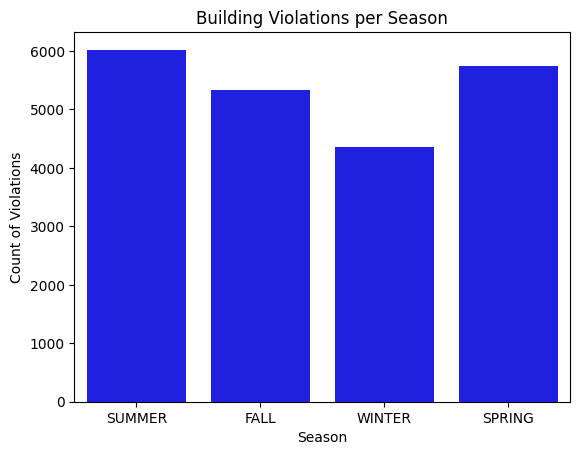

Perform another filtering step. This time, filter your dataset so that only rows with the 5 most common types of Case Disposition remain.

1. How many rows does your dataframe contain now?
- 20,827
2. Make histograms that depict CityDelay. Color your bars. Be mindful of outliers when you decide on setting your plot axes. Each Case Disposition should have a separate histogram.
3. In a sentence or two, describe your plot - what does it show? What could explain these results? Pick at least 2-3 of these that stand out to you, and offer some thoughts about why they look the way they do.
- Although there is a large number of 'Non Suit' cases, the city delay tends to be relatively low, with most cases being resolved inside 300 days, likely due to the nature of these cases being quite simple.
- When the case dispostion is 'Liable', the city delay tends to be longer, with most cases falling outside of the 200+ days range. The case being 'Liable' means that someone is usually at fault, which would explain the city delay as it can take time to gather all the relevant details surrounding a case, especially if some legal action is to be taken surrounding the imposed fine.
- The bins for the 'Default' case dispostion are quite large and inconsistent with the rest of the data. I created a table below to shed some light on this. The top 20 city delay times for 'Default' all fall under a range of 35 - 56, the max delay for the graphs of CityDelay is 650 and I've chosen 30 bins to represent the data. Therefore all of this data is being clumped into what looks like one massive bin. To mediate this 'Default' could be analyzed seperately on its own plot to give a more presentable visualization.

```
top_5_disposition = chicago_ward_9['CASE DISPOSITION'].value_counts().head(5).index
chicago_ward_9_top_5 = chicago_ward_9[chicago_ward_9['CASE DISPOSITION'].isin(top_5_disposition)]
len(chicago_ward_9_top_5)
```

```
20827
```

```
print(chicago_ward_9_top_5['CASE DISPOSITION'].value_counts())
```

```
CASE DISPOSITION
Non-Suit       6690
Liable         6397
Default        4032
Not Liable     2686
Continuance    1022
Name: count, dtype: int64
```

```
city_delay_count_top5 = chicago_ward_9_top_5[chicago_ward_9_top_5['CASE DISPOSITION'] == 'Default']['CityDelay'] .value_counts().head(20)
city_delay_count_top5
```

| CityDelay | count |
| --- | --- |
| 78.0 | 56 |
| 76.0 | 55 |
| 151.0 | 51 |
| 202.0 | 49 |
| 117.0 | 49 |
| 181.0 | 42 |
| 62.0 | 42 |
| 58.0 | 41 |
| 68.0 | 40 |
| 56.0 | 40 |
| 272.0 | 40 |
| 257.0 | 40 |
| 159.0 | 39 |
| 51.0 | 37 |
| 198.0 | 37 |
| 180.0 | 36 |
| 281.0 | 36 |
| 142.0 | 35 |
| 148.0 | 35 |
| 132.0 | 35 |

```
chicago_ward_9_top_5.head()
```

[output not shown]

```
max_delay = 650

City_Delay_Hist = sns.FacetGrid(
    chicago_ward_9_top_5,
    col="CASE DISPOSITION",
    col_wrap=3,
    height=4,
    sharex=True,
    sharey=False)

City_Delay_Hist.map_dataframe(
    sns.histplot,
    x="CityDelay",
    bins=30,
    color="skyblue",
    edgecolor="white")

City_Delay_Hist.set_axis_labels("City Delay (days)", "Count")
City_Delay_Hist.set(xlim=(0, max_delay))
City_Delay_Hist.set_titles("{col_name}")
City_Delay_Hist.fig.suptitle("CityDelay Distribution by Case Disposition", y=1.02, fontsize=14, fontweight="bold")

plt.tight_layout()
plt.show()
```

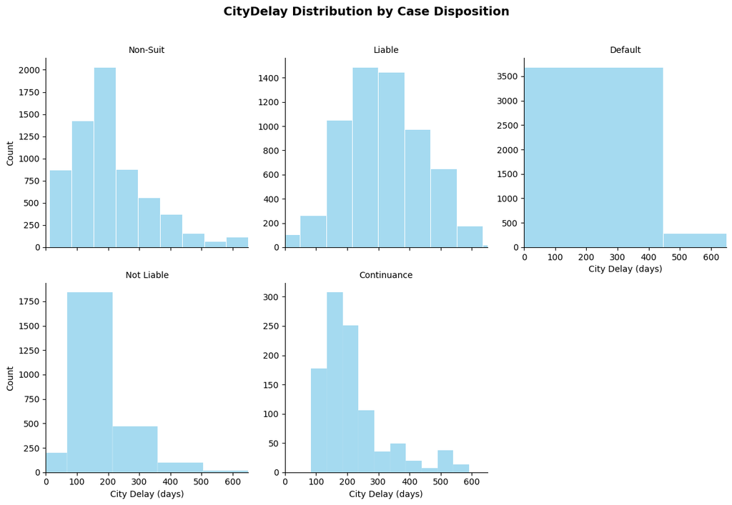

Build another barplot now. For this plot, place the Case Disposition on the x-axis. The y-axis should show the average imposed fine for each type of case disposition. Be sure to color your bars, and to order them (either largest to smallest, or smallest to largest).

What does this plot show? Offer some explanation – what might help to explain the reason why it looks this way? Speculate a bit about these differences from group to group

- The plot gives us some interesting insights. Although the count of Non-Suit fines are the highest at over 6000, the average imposed fine for each disposition is extremely low relative to other fines as these cases usually occur when cases aren't pursued or dismissed which doesn't result in an actual 'fine', many of these violations did not incur any fine at all.
- I was surprised to see the average Default fine to be so high. Typically to 'default' on something is to fail to fulfill an obligation. In this case I would imagine these fines to be so high due to the defendants continuing to fail to pay violation fines and in certain cases failing to appear in court which can lead to a hefty fine being issued due to the waste in resources.

```
order = (chicago_ward_9_top_5.groupby('CASE DISPOSITION')['IMPOSED FINE'].mean().sort_values(ascending = False).index)

avg_fine_plot = sns.barplot(x = 'CASE DISPOSITION', y = 'IMPOSED FINE', data = chicago_ward_9_top_5, order = order, errorbar= None, color = 'red')
plt.title('Average Imposed Fine by Case Disposition')
plt.xlabel('Case Disposition')
plt.ylabel('Average Imposed Fine');
```

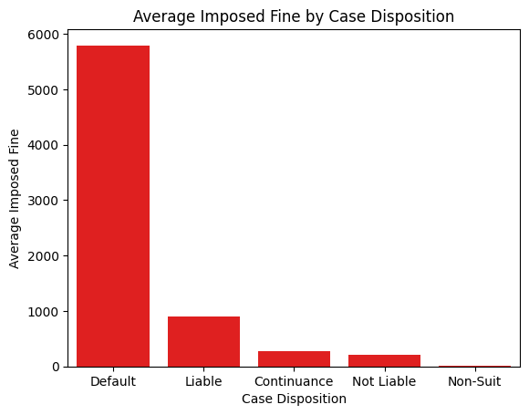

Now, make a histogram that depicts the distribution of Admin Costs along the x-axis. For your fill variable, use Case Disposition. Set either the bins or binwidth argument on this histogram so that you do not see any gaps between the bins when viewing the plot.

What does your plot show? Describe in a few sentences, pointing out anything particularly noteworthy or interesting. What might explain the way it looks?

- As mentioned above, the costs associated with 'Non Suit' & 'continuance' cases are quite low which explains the count of the admin costs between 0 - 20 dollars to be so high.
- The admin costs associated with 'Liable' & 'Default' cases tend to be a lot higher ranging mostly from 40 - 80 dollars which makes sense due to the higher costs that may be incurred when persuing a case as apposed to throwing one out.
- It was interesting to note there were no admin costs incurred between 20 - 40 dollars & 80 - 100 dollars so I removed these from the bins to ensure the plot had no gaps however I feel the original plot with gaps was visually more appealing.

```
sns.histplot(x = 'ADMIN COSTS', data = chicago_ward_9_top_5, bins = [0,20,60,80,120], hue = 'CASE DISPOSITION',
             multiple = 'stack', palette = 'Set2')
plt.title('Distribution of Admin Costs by Case Disposition')
plt.xlabel('Admin Costs')
plt.ylabel('Count');
```

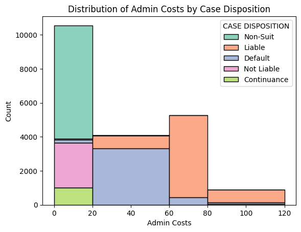

Perform another filtering step. This time, filter your dataset so that only rows with the 5 most common types of Violation Description remain.

Right now, you have just a few unique values for Violation Description. What are they? It looks like these are pretty long! Shorten these names in the dataset to something much more manageable – these should become short enough so that they could be used as labels in a visualization. Each description should just be reduced to 1-2 words.

```
top_5_violation = chicago_ward_9_top_5['VIOLATION DESCRIPTION'].value_counts().head(5).index
chicago_ward_9_top_5_new = chicago_ward_9_top_5[chicago_ward_9_top_5['VIOLATION DESCRIPTION'].isin(top_5_violation)]
```

```
chicago_ward_9_top_5_new['VIOLATION DESCRIPTION'].value_counts()
```

| VIOLATION DESCRIPTION | count |
| --- | --- |
| Arrange for inspection of premises. (13-12-100) | 1077 |
| Repair or replace defective or missing members of porch system. (13-196-570) | 718 |
| Repair exterior wall. (13-196-010, 13-196-530 B) | 710 |
| Replace broken, missing or defective window panes. (13-196-550 A) | 552 |
| Post name, address, and telephone of owner, owner's agent for managing, controlling or collecting rents, and any other person managing or controlling building conspicuously where accessible or visible… | 490 |

```
short_names = {'Arrange for inspection of premises. (13-12-100)' : 'Premises Inspection',
'Repair exterior wall. (13-196-010, 13-196-530 B)' : 'Wall Repair',
'Repair or replace defective or missing members of porch system. (13-196-570)' : 'Porch  Maintenance',
 'Replace broken, missing or defective window panes. (13-196-550 A)' : 'Window Maintenance',
 'Post name, address, and telephone of owner, owners agent for managing, controlling or collecting rents, and any other person managing or controlling building conspicuously where accessible or visible to public way. (13-12-030)' : 'Administrative Violation'}
```

```
chicago_ward_9_top_5_new['Short Violation'] = chicago_ward_9_top_5_new['VIOLATION DESCRIPTION'].map(short_names)
chicago_ward_9_top_5_new.head()
```

[output not shown]

[output not shown]

Now, create a barplot that depicts the mean Imposed Fine value for each of these five violation descriptions. Fill the bars with any color of your choice. Arrange the bars either in increasing or decreasing order. What does this plot show? Speculate a bit about why some types of violations may receive larger fines, compared with others.

- It is unsurprising to see that the highest average fines are issued for maintenance or repair violations. These fines can be quiet high due to the cost in labor and materials needed to mediate these violations.
- Administrative & inspection violations will not accrue such high penalties as there are no extra raw materials required to mediate these violations. The only cost incurred is the penalty itself and cost of labor.

```
chicago_ward_9_top_5_new.loc[:, 'Short Violation'] = (
    chicago_ward_9_top_5_new['VIOLATION DESCRIPTION'].replace(short_names))
```

```
chicago_ward_9_top_5_new.loc[
    chicago_ward_9_top_5_new['VIOLATION DESCRIPTION'].str.contains("Post name", case=False, na=False),
    'Short Violation'] = "Administrative Violation"
```

```
mean_fines = chicago_ward_9_top_5_new.groupby('Short Violation')['IMPOSED FINE'].mean().sort_values(ascending = False)
mean_fines
```

| Short Violation | IMPOSED FINE |
| --- | --- |
| Window Maintenance | 1691.621377 |
| Wall Repair | 1528.485915 |
| Porch Maintenance | 1392.130919 |
| Administrative Violation | 1232.295918 |
| Premises Inspection | 1020.844940 |

```
sns.barplot(x = mean_fines.index, y = mean_fines.values, color = 'blue')
plt.xticks(rotation = 45, ha = 'right')
plt.title('Mean Imposed Fine by Violation Description')
plt.xlabel('Violation Description')
plt.ylabel('Mean Imposed Fine');
```

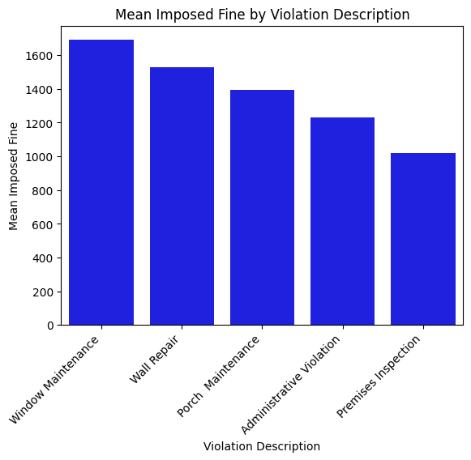

Write this statement here: My assignment submission includes the following:

1. A file containing code
2. A write-up in a PDF that clearly includes all of my code, results, and interpretation statements, together